# 白葡萄酒数据分析 – elninowang

本报告探讨了一个包含约4898种白酒的以及其化学成分。 主要的目的找到对白酒质量影响大的化学成分有哪些

# 单一变量绘图部分

看一下有哪些属性

```
##  [1] "X"                    "fixed.acidity"        "volatile.acidity"
##  [4] "citric.acid"          "residual.sugar"       "chlorides"
##  [7] "free.sulfur.dioxide"  "total.sulfur.dioxide" "density"
## [10] "pH"                   "sulphates"            "alcohol"
## [13] "quality"
```

### 各种质量的白酒的数量分布

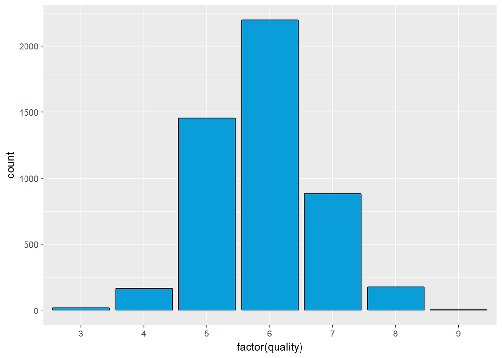

可以看出，质量为6的白葡萄酒最多，两边都依次递减

### 探索每中化学成本在整体数据的占比情况

成分: fixed.acidity: 固定酸度：葡萄酒中涉及的大多数酸或固定或非挥发性（不易挥发）

```
##    Min. 1st Qu.  Median    Mean 3rd Qu.    Max.
##   3.800   6.300   6.800   6.855   7.300  14.200
```

```
##
## 6.8 6.6 6.4 6.9 6.7   7 6.5 7.2 7.1 7.4 6.2 6.3   6 7.3 6.1 7.6 7.5 5.8
## 308 290 280 241 236 232 225 206 200 194 192 188 184 178 155 153 123 121
## 5.9 7.7
## 103  93
```

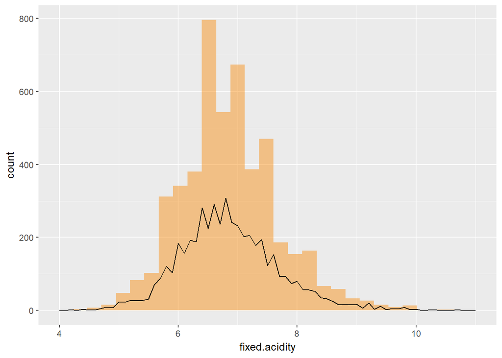

成分volatile.acidity 挥发性酸度：葡萄酒中醋酸的含量过高会导致醋的味道不舒服

```
##    Min. 1st Qu.  Median    Mean 3rd Qu.    Max.
##  0.0800  0.2100  0.2600  0.2782  0.3200  1.1000
```

```
##
## 0.28 0.24 0.26 0.25 0.22 0.27 0.23  0.2  0.3 0.21 0.32 0.18 0.19 0.29 0.31
##  263  253  240  231  229  218  216  214  198  191  182  177  170  160  148
## 0.16 0.17 0.34 0.33 0.36
##  141  140  135  134  104
```

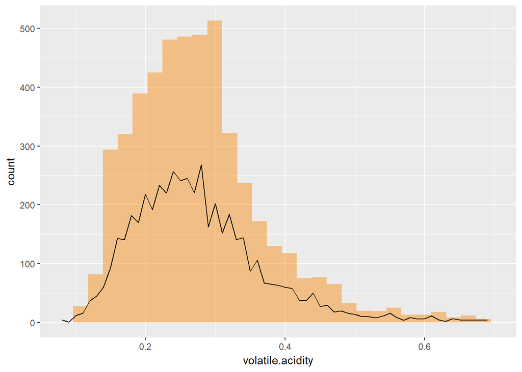

成分: citric.acid 柠檬酸：少量发现，柠檬酸可以增加“新鲜”和风味的葡萄酒

```
##    Min. 1st Qu.  Median    Mean 3rd Qu.    Max.
##  0.0000  0.2700  0.3200  0.3342  0.3900  1.6600
```

```
##
##  0.3 0.28 0.32 0.34 0.29 0.26 0.27 0.49 0.31 0.33 0.24 0.36 0.35 0.25 0.37
##  307  282  257  225  223  219  216  215  200  183  181  177  137  136  134
## 0.38  0.4 0.22 0.39 0.42
##  122  117  104  101   95
```

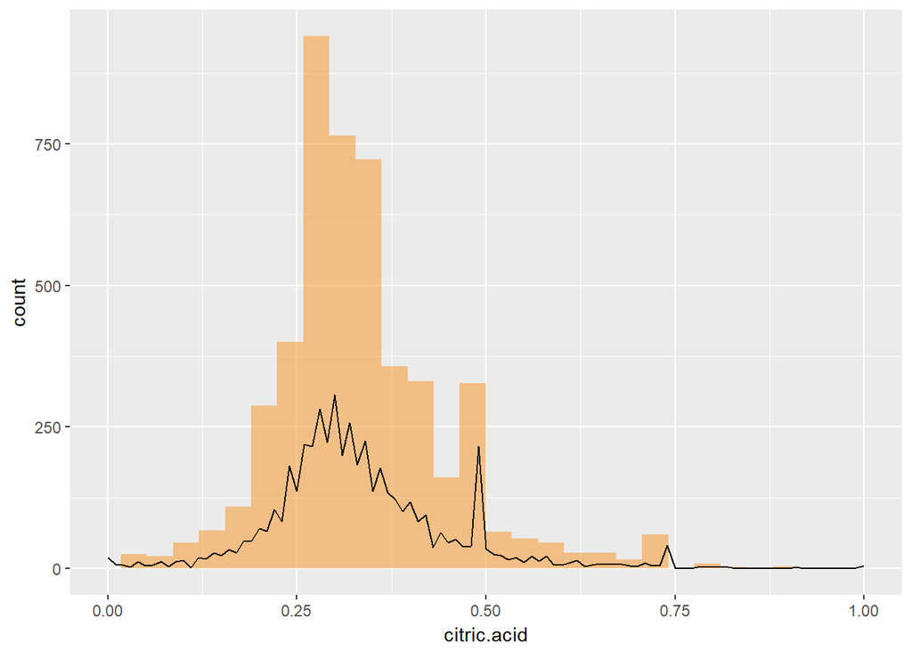

成分: residual.sugar 残糖：发酵停止后的剩余糖量，少于1克/升的葡萄酒很少见，而高于45克/升的葡萄酒被认为是甜的

```
##    Min. 1st Qu.  Median    Mean 3rd Qu.    Max.
##   0.600   1.700   5.200   6.391   9.900  65.800
```

```
##
## 1.2 1.4 1.6 1.3 1.1 1.5 1.7 1.8   1   2 1.9 2.2 2.1   5 2.3 2.4 7.8 2.5
## 187 184 165 147 146 142  99  99  93  79  59  56  51  43  42  41  41  40
## 4.6 7.4
##  40  40
```

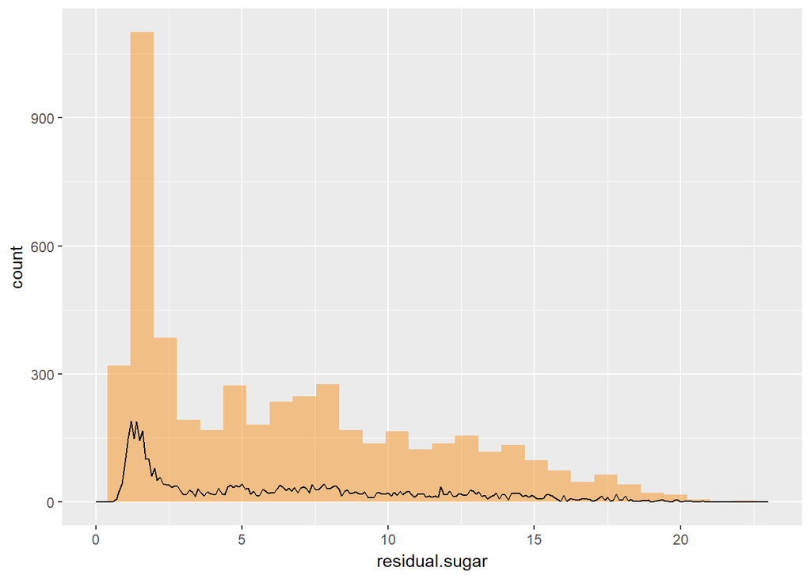

成分: chlorides 氯化物：酒中的盐量

```
##    Min. 1st Qu.  Median    Mean 3rd Qu.    Max.
## 0.00900 0.03600 0.04300 0.04577 0.05000 0.34600
```

```
##
## 0.044 0.036 0.042  0.04 0.046 0.048 0.047 0.045  0.05 0.034 0.038 0.037
##   201   200   184   182   181   174   171   170   170   168   167   160
## 0.039 0.041 0.043 0.049 0.035 0.053 0.033 0.051
##   157   147   141   133   130   130   119   115
```

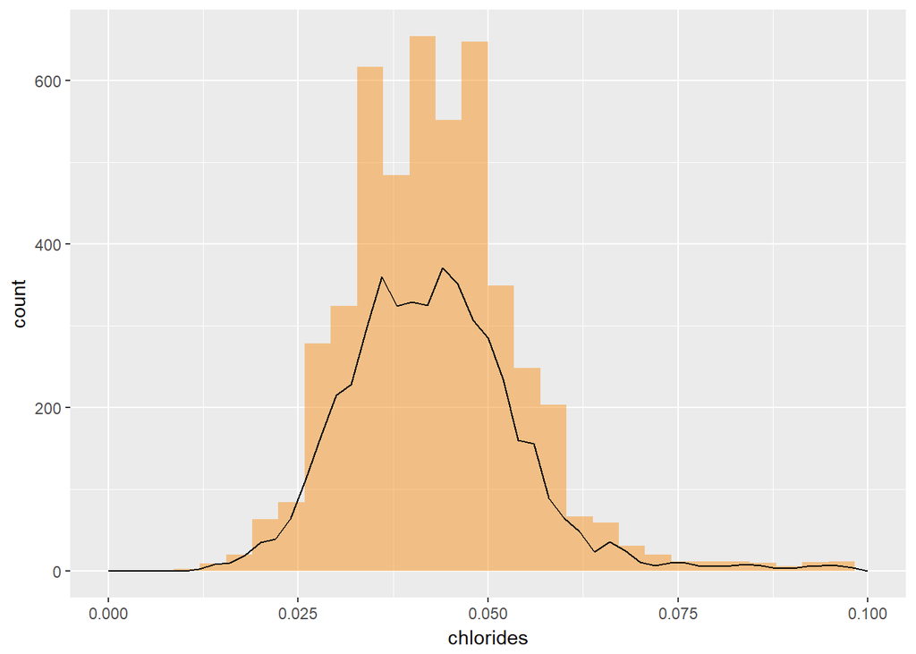

成分: free.sulfur.dioxide 游离二氧化硫：SO2的游离形式存在于分子SO2（作为溶解气体）和亚硫酸氢根离子的平衡状态; 它可以防止微生物的生长和葡萄酒的氧化

```
##    Min. 1st Qu.  Median    Mean 3rd Qu.    Max.
##    2.00   23.00   34.00   35.31   46.00  289.00
```

```
##
##  29  31  26  35  34  36  24  28  33  25  37  23  32  41  40  22  38  20
## 160 132 129 129 128 127 118 112 112 111 111 110 109 104 103 102 102 101
##  45  27
## 101  99
```

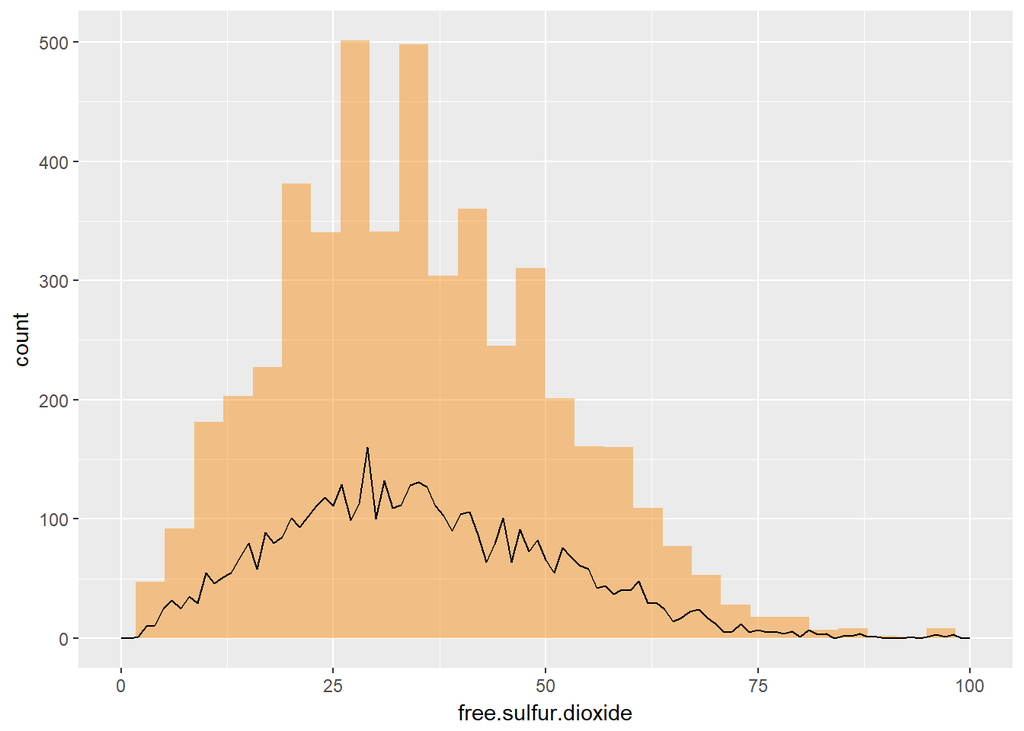

成分: total.sulfur.dioxide 总二氧化硫：游离和结合形式的SO 2的量; 在低浓度下，SO2在葡萄酒中几乎检测不到，但是当游离SO2浓度超过50ppm时，SO2在葡萄酒的鼻子和味道中变得明显

```
##    Min. 1st Qu.  Median    Mean 3rd Qu.    Max.
##     9.0   108.0   134.0   138.4   167.0   440.0
```

```
##
## 111 113 117 118 114 122 128 150 124 140 126 133  98 125 149 101 110 116
##  69  61  57  55  54  54  54  54  53  52  50  50  49  49  48  47  47  47
## 119 131
##  47  47
```

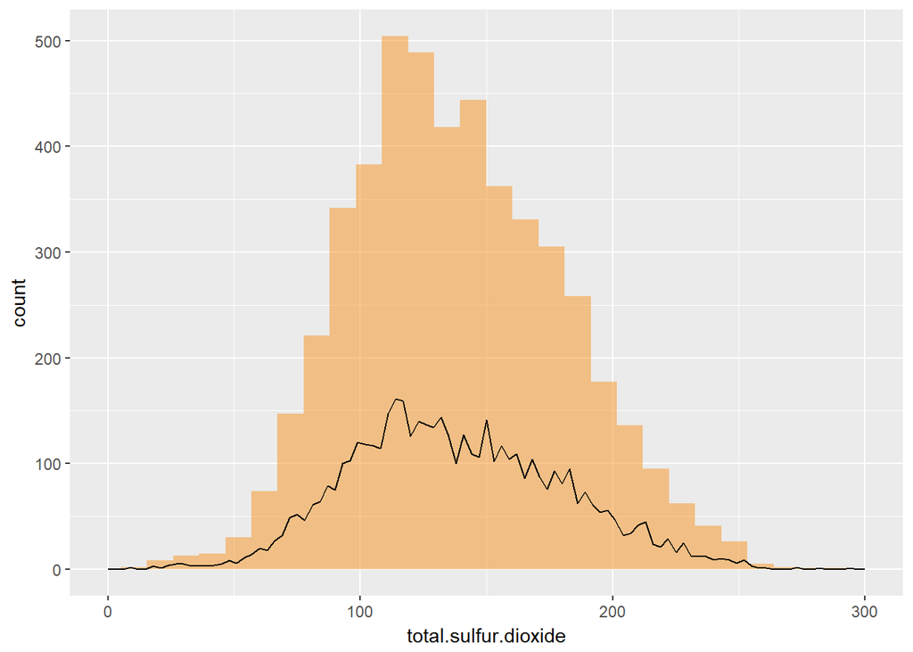

属性：density 密度：取决于酒精和糖的百分比，水的密度接近于水的密度

```
##    Min. 1st Qu.  Median    Mean 3rd Qu.    Max.
##  0.9871  0.9917  0.9937  0.9940  0.9961  1.0390
```

```
##
##  0.992 0.9928 0.9932  0.993 0.9934 0.9938 0.9927 0.9944 0.9948 0.9924
##     64     61     53     52     50     49     47     46     45     44
## 0.9954 0.9986 0.9956 0.9918 0.9958 0.9914 0.9942  0.994 0.9952 0.9966
##     44     42     41     40     40     39     38     37     37     36
```

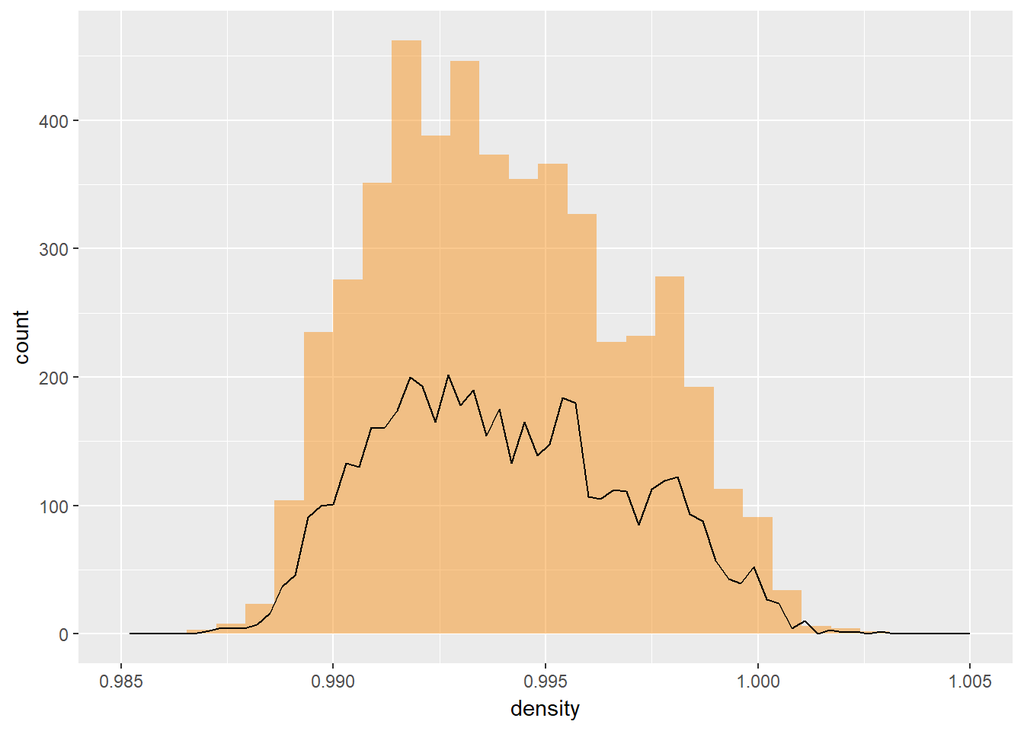

属性: pH pH值：描述葡萄酒的酸度或碱度是从0（非常酸性）到14（非常碱性）的标准。 大多数葡萄酒的pH值在3-4之间

```
##    Min. 1st Qu.  Median    Mean 3rd Qu.    Max.
##   2.720   3.090   3.180   3.188   3.280   3.820
```

```
##
## 3.14 3.16 3.22 3.19 3.18  3.2 3.08 3.15  3.1 3.12 3.24 3.11 3.17 3.13 3.23
##  172  164  146  145  138  137  136  136  135  134  132  126  124  117  116
## 3.06 3.25 3.04 3.26 3.21
##  115  114   97   96   95
```

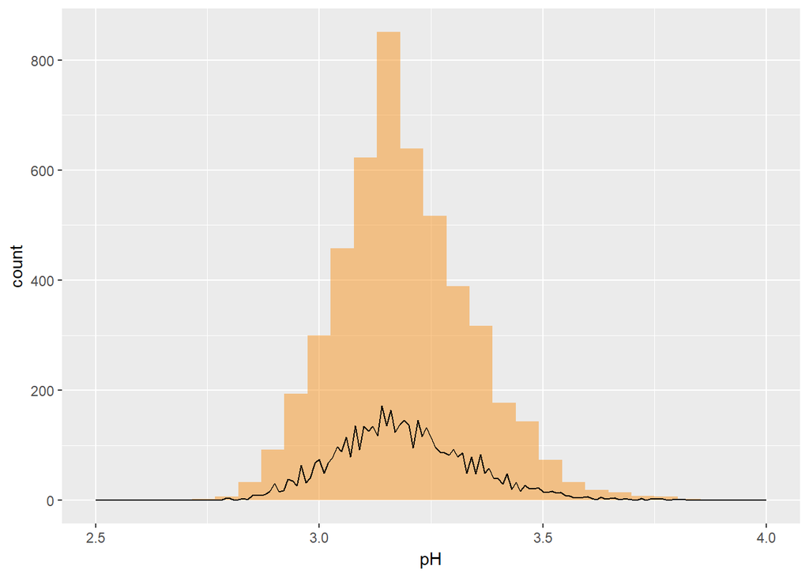

成分：sulphates 硫酸盐：一种能够促成二氧化硫气体（SO 2）水平的葡萄酒添加剂，它起抗菌剂和抗氧化剂的作用

```
##    Min. 1st Qu.  Median    Mean 3rd Qu.    Max.
##  0.2200  0.4100  0.4700  0.4898  0.5500  1.0800
```

```
##
##  0.5 0.46 0.44 0.38 0.42 0.48 0.45 0.47  0.4 0.54 0.49 0.43 0.52 0.39 0.51
##  249  225  216  214  181  179  178  172  168  167  166  161  156  151  140
## 0.41 0.53 0.37 0.36 0.56
##  139  135  129  120  108
```

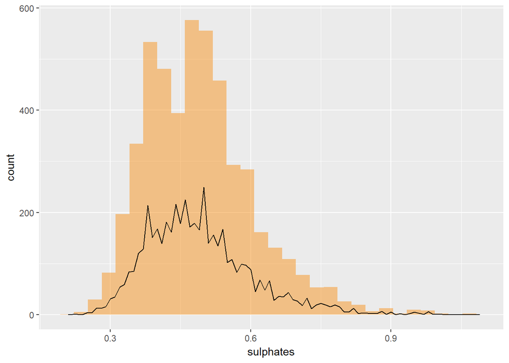

成分: alcohol 酒精：酒的百分比酒精含量

```
##    Min. 1st Qu.  Median    Mean 3rd Qu.    Max.
##    8.00    9.50   10.40   10.51   11.40   14.20
```

```
##
##  9.4  9.5  9.2    9   10 10.5   11 10.4  9.1  9.8 10.8  9.3 10.2  9.6 11.4
##  229  228  199  185  162  160  158  153  144  136  135  134  130  128  121
## 10.1 10.6 11.2  9.9  8.8
##  114  114  112  109  107
```

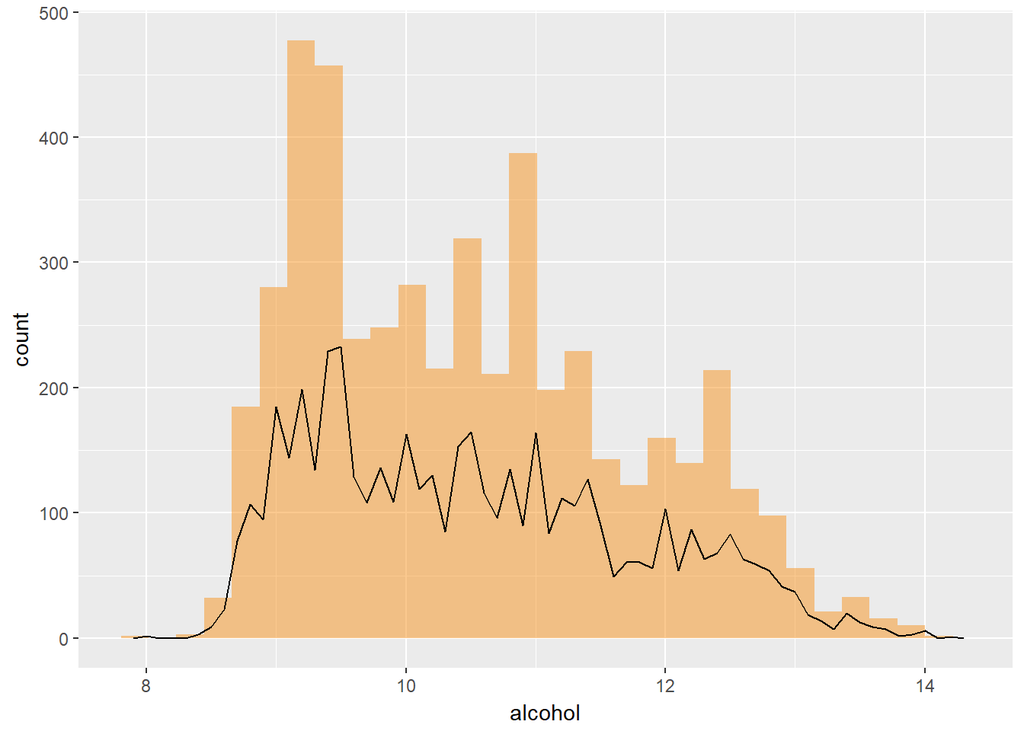

# 单变量分析

### 你的数据集的结构是什么？

数据集中有4898种白酒，具有11个特征

- 固定酸度（酒石酸 - g/dm^3）
- 挥发酸度（乙酸 - g/dm^3）
- 柠檬酸（g/dm^3）
- 残糖（g/dm^3）
- 氯化物（氯化钠 - g/dm^3
- 游离二氧化硫（mg/dm^3）
- 总二氧化硫（mg/dm^3）
- 密度（g/cm^3）
- pH
- 硫酸盐（硫酸钾 - g/dm3）
- 酒精（体积百分比）

都是变量，没有有序因子变量

### 数据集中的主要特征是什么？

一些属性是大致程正态分布状

- 白葡萄酒质量 quality
- 氯化物 chlorides
- pH
- 游离二氧化硫值 free.sulfur.dioxide
- 总二氧化硫 total.sulfur.dioxide
- 密度 density

其他属性都程 成靠前的正态分布模式

### 您认为数据集中还有哪些其他功能可以帮助您调查您感兴趣的功能？

通过以上的图示分析，通过单变量分析，还看不出，哪些对我评估白葡萄酒有关

### 您是否从数据集中的现有变量创建了任何新变量？

目前看来还不需要

### 你调查的功能中，有没有不寻常的分布？ 您是否对数据进行了任何操作来整理，调整或更改数据的形式？ 如果是这样，你为什么这样做？

有不寻常分布 如柠檬酸 citric.acid，有两个头，一个是0.3左右，一个是在0.49左右。

另外有些个别点值相差甚远，我做了裁剪，过滤掉了太大或者大小的数据。

# 双变量绘图部分

探测每两个属性之间的相关性

```
##           fxd_ac vlt_ac  ctc_ac  sugar chlorides  free_sd total_sd   dens
## fxd_ac     1.000 -0.023  0.2892  0.089     0.023 -0.04940   0.0911  0.265
## vlt_ac    -0.023  1.000 -0.1495  0.064     0.071 -0.09701   0.0893  0.027
## ctc_ac     0.289 -0.149  1.0000  0.094     0.114  0.09408   0.1211  0.150
## sugar      0.089  0.064  0.0942  1.000     0.089  0.29910   0.4014  0.839
## chlorides  0.023  0.071  0.1144  0.089     1.000  0.10139   0.1989  0.257
## free_sd   -0.049 -0.097  0.0941  0.299     0.101  1.00000   0.6155  0.294
## total_sd   0.091  0.089  0.1211  0.401     0.199  0.61550   1.0000  0.530
## dens       0.265  0.027  0.1495  0.839     0.257  0.29421   0.5299  1.000
## pH        -0.426 -0.032 -0.1637 -0.194    -0.090 -0.00062   0.0023 -0.094
## sul       -0.017 -0.036  0.0623 -0.027     0.017  0.05922   0.1346  0.074
## alco      -0.121  0.068 -0.0757 -0.451    -0.360 -0.25010  -0.4489 -0.780
## qual      -0.114 -0.195 -0.0092 -0.098    -0.210  0.00816  -0.1747 -0.307
##                 pH    sul   alco    qual
## fxd_ac    -0.42586 -0.017 -0.121 -0.1137
## vlt_ac    -0.03192 -0.036  0.068 -0.1947
## ctc_ac    -0.16375  0.062 -0.076 -0.0092
## sugar     -0.19413 -0.027 -0.451 -0.0976
## chlorides -0.09044  0.017 -0.360 -0.2099
## free_sd   -0.00062  0.059 -0.250  0.0082
## total_sd   0.00232  0.135 -0.449 -0.1747
## dens      -0.09359  0.074 -0.780 -0.3071
## pH         1.00000  0.156  0.121  0.0994
## sul        0.15595  1.000 -0.017  0.0537
## alco       0.12143 -0.017  1.000  0.4356
## qual       0.09943  0.054  0.436  1.0000
```

图标看每两个属性之间的相关性

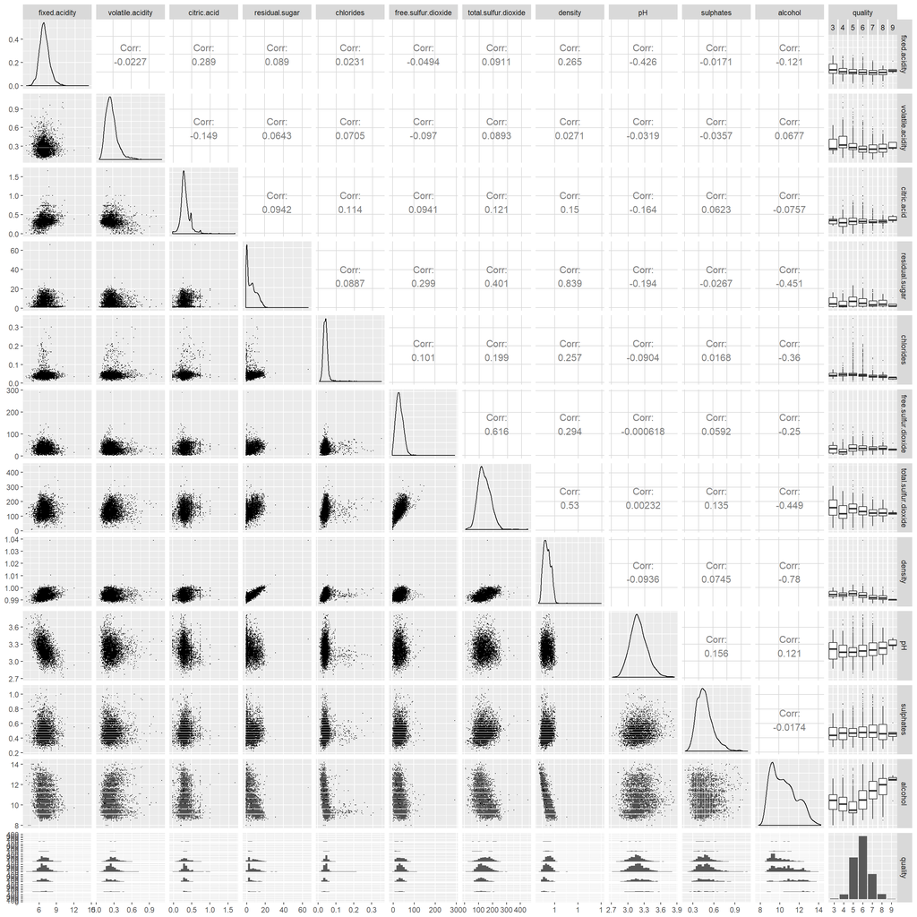

从以上表格中可以看出，酒精含量(alcohol)和密度（density）具有很强的相关性，我们单独绘制散点图看看

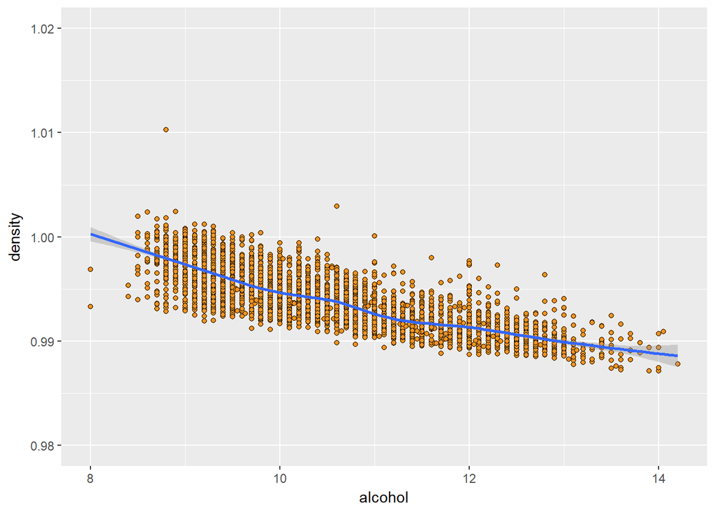

由此看出 酒精越多，密度越低

我们下面分别看一下密度 和 酒精

我们先看看密度

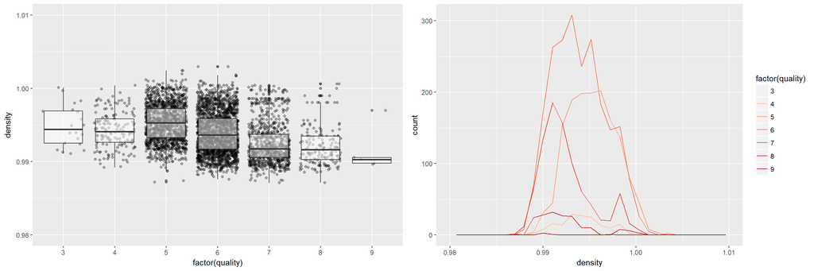

这样看不出，不同质量下密度的线，下面我们分质量汇出密度的线：

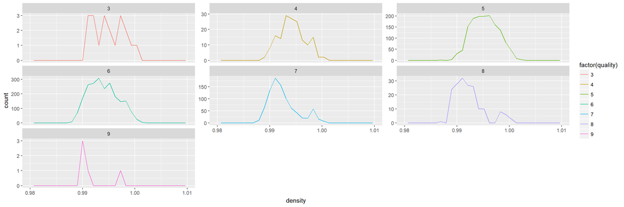

我们看看酒精的情况

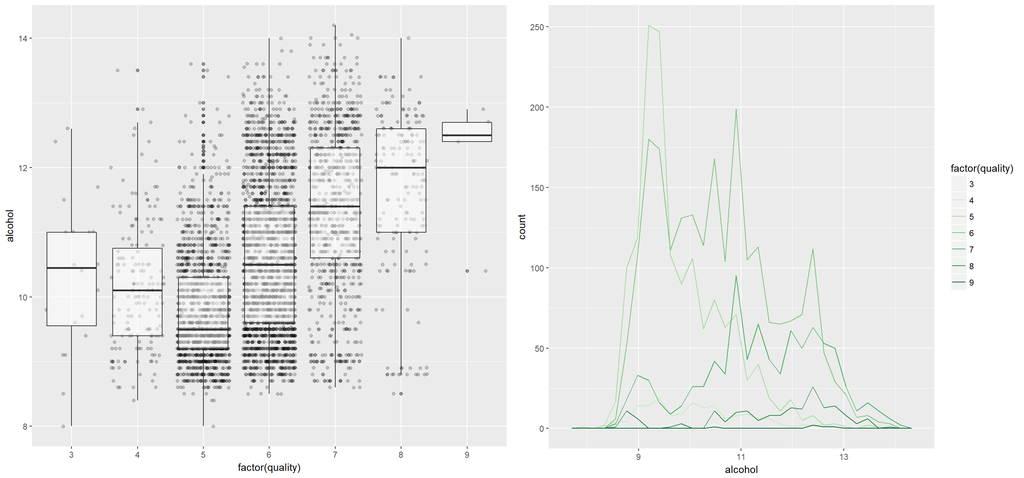

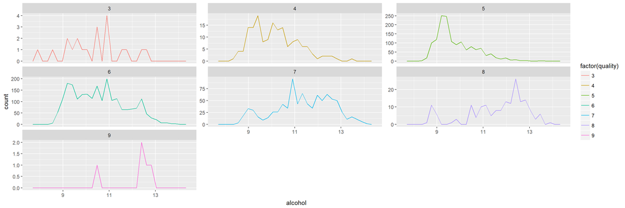

从相关性矩阵中可以看出 密度(density) 和 残糖(residual.sugar) 之间也有较强的相关性

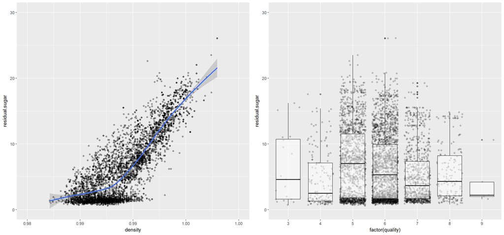

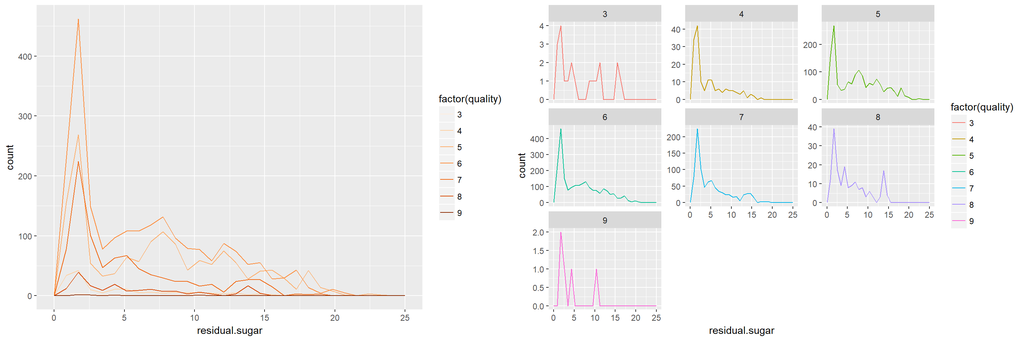

基本上可以看出，残糖越多(residual.sugar), 密度(density) 越高；但是看不出残糖(residual.sugar)和最终的质量(quality)有什么直接的关系

从相关性矩阵中可以看出 游离二氧化硫(free.sulfur.dioxide) 和 总二氧化硫(total.sulfur.dioxide) 之间也有较强的相关性

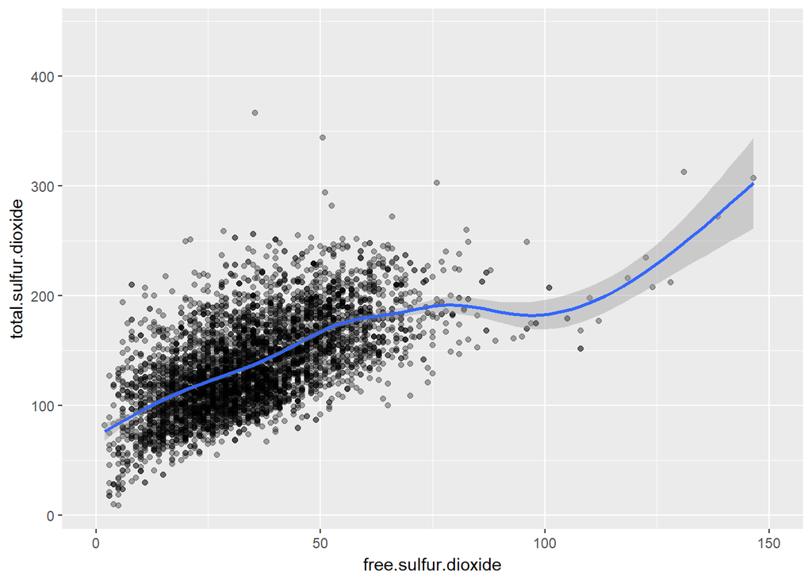

可以看出这两个变量是同增同减少关系，不过没有找到这两个成本 直接和最后的质量(quatity)有什么关系

从相关性矩阵中可以看出 密度(density) 和 总二氧化硫(total.sulfur.dioxide) 之间也有较强的相关性

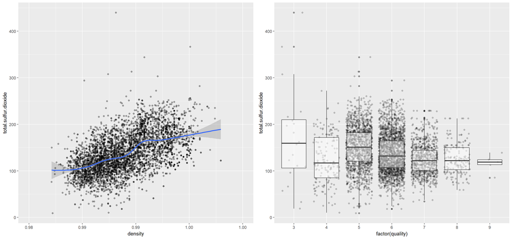

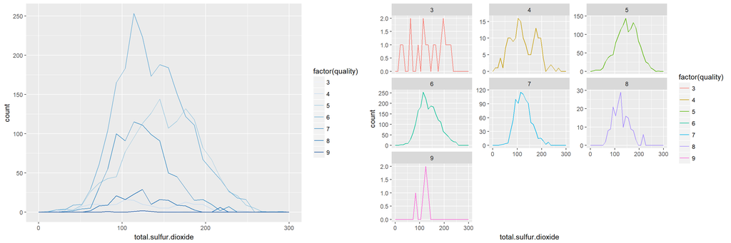

可以看出 总二氧化汤(total.sulfur.dioxide) 和 密度(density) 确实有近似的关系，但是和最终的质量(quality)没有直接的关系

我们再看看游离二氧化碳(free.sulfur.dioxide) 和 密度(density) 之间的的关系

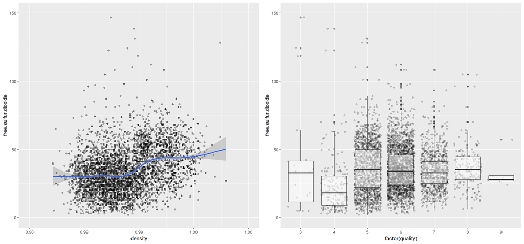

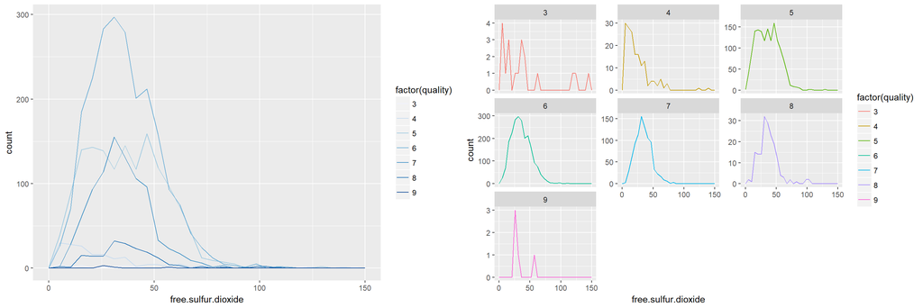

可以看出，游离二氧化碳(free.sulfur.dioxide) 和 密度(density) 之间 确实有些关系，但是关系不如总二氧化碳那么大

# 双变量分析

### 谈谈你在这部分调查中观察到的一些关系。 感兴趣的特征如何随着数据集中的其他特征而变化？

质量(quality), 密度(density) 和 酒精含量(alcohol) 有着强关联

大体来说，酒精含量(alcohol)越高，质量(quality)越好，密度越低(desinty)越低，质量(quality)越好

### 您是否观察到其他特征（不是感兴趣的主要特征）之间的任何有趣关系？

游离二氧化硫(free.sulfur.dioxide)和总二氧化硫(total.sulfur.dioxide)之间也是强关联，同增同减关系

另外 总二氧化汤( total.sulfur.dioxide) 和 密度(density) 也有一定的关联，近似同增同减的关系

# 多变量绘图部分

我们首先看看在不同密度(density)和酒精按量(alchohol)下的 白葡萄酒质量(quality)的表现

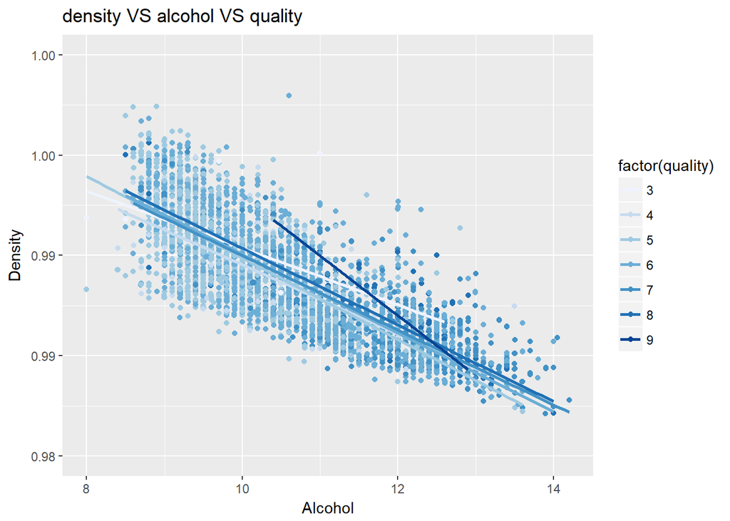

```
##    Min. 1st Qu.  Median    Mean 3rd Qu.    Max.
##       2      23      34      35      46     289
```

```
##
##  29  31  26  35  34  36  24  28  33  25  37  23  32  41  40  22  38  20
## 160 132 129 129 128 127 118 112 112 111 111 110 109 104 103 102 102 101
##  45  27  30  21  47  17  39  42  19  49  18  15  44  52  14  53  48  46
## 101  99  99  93  91  89  89  86  84  82  80  79  75  72  68  68  66  64
##  50  43  54  16
##  64  63  61  58
```

对 游离二氧化碳进行分组, 分为 (,23],(23,30],(30,38],(38,46],(46,289]

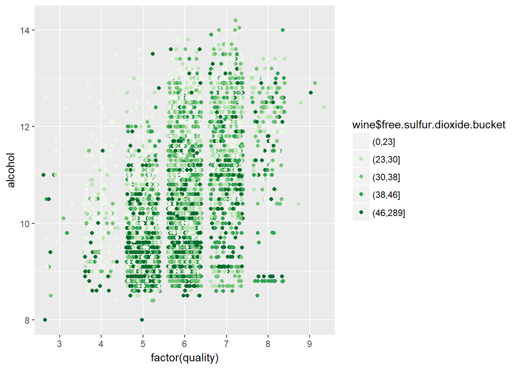

没有看出 质量(quality) 的规律, 换中方法绘图看看

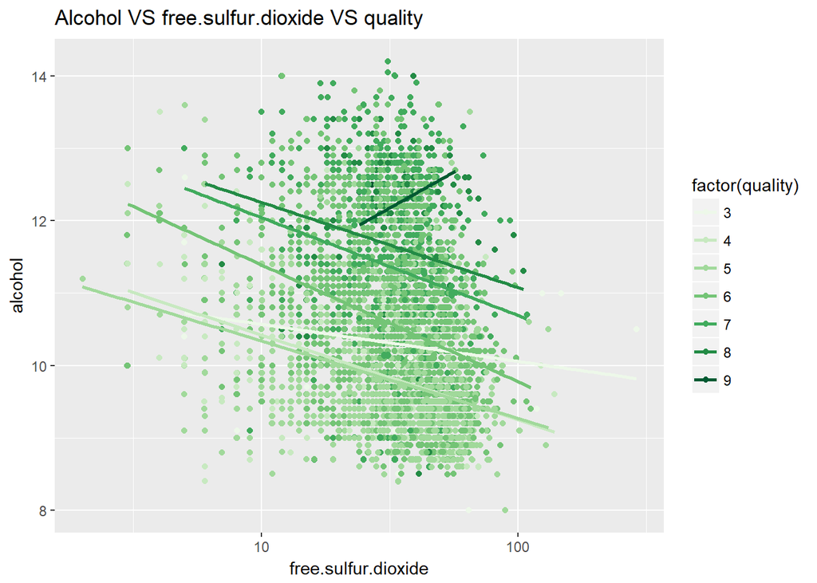

可以看出在酒精含量比较高的时候，游离二氧化碳（free.sulfur.dioxide）越多，白酒的质量(quality)越好

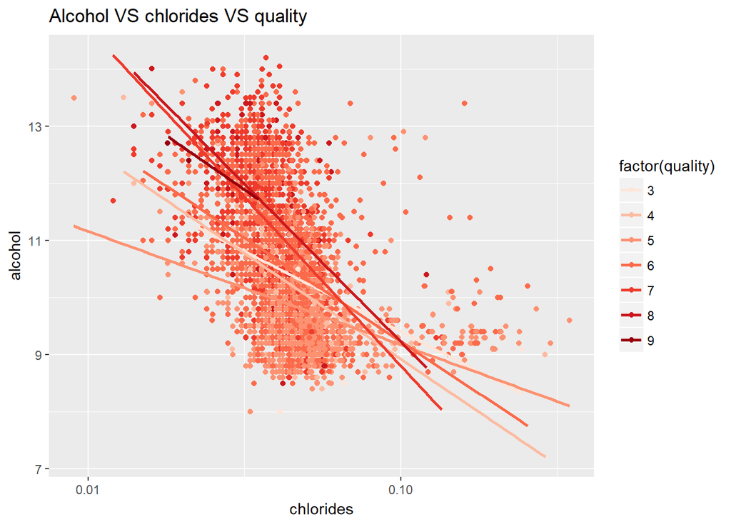

可以看出 在酒精含量的情况下， 氯化物(chlorids)越低，质量(quality)越高

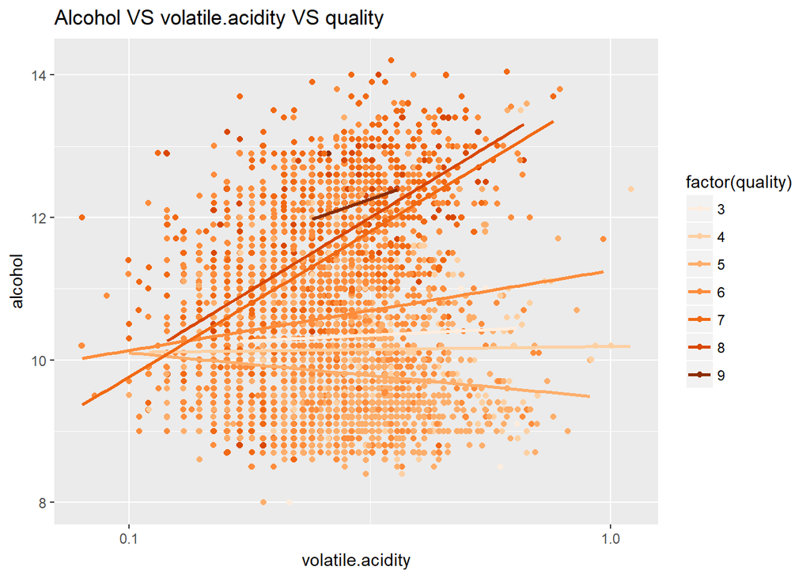

可以看出，酒精含量不高的时候，挥发性酸度（volatile acidity）约低，白酒的质量quality越高

```
##
## Calls:
## m1: lm(formula = I(quality) ~ I(alcohol), data = wine)
## m2: lm(formula = I(quality) ~ I(alcohol) + log(free.sulfur.dioxide),
##     data = wine)
## m3: lm(formula = I(quality) ~ I(alcohol) + log(chlorides), data = wine)
## m4: lm(formula = I(quality) ~ I(alcohol) + log(volatile.acidity),
##     data = wine)
##
## ================================================================================
##                                 m1           m2           m3           m4
## --------------------------------------------------------------------------------
##   (Intercept)                   2.58***      1.08***      2.24***      1.67***
##                                (0.10)       (0.13)       (0.12)       (0.11)
##   I(alcohol)                    0.31***      0.35***      0.29***      0.32***
##                                (0.01)       (0.01)       (0.01)       (0.01)
##   log(free.sulfur.dioxide)                   0.33***
##                                             (0.02)
##   log(chlorides)                                         -0.20***
##                                                          (0.04)
##   log(volatile.acidity)                                               -0.60***
##                                                                       (0.03)
## --------------------------------------------------------------------------------
##   R-squared                     0.19         0.23         0.19         0.24
##   adj. R-squared                0.19         0.23         0.19         0.24
##   sigma                         0.80         0.78         0.80         0.77
##   F                          1146.40       732.92       588.03       778.50
##   p                             0.00         0.00         0.00         0.00
##   Log-likelihood            -5839.39     -5713.11     -5827.30     -5678.26
##   Deviance                   3112.26      2955.84      3096.93      2914.08
##   AIC                       11684.78     11434.22     11662.60     11364.52
##   BIC                       11704.27     11460.20     11688.58     11390.51
##   N                          4898         4898         4898         4898
## ================================================================================
```